# BellaBeat Case Study - Google Data Analytics Professional Certificate

Adrian Lehrner

2023-06-20

# Project Overview: BellaBeat Case Study

The BellaBeat Case Study is part of the Google Data Analytics Professional Certificate program and focuses on analyzing data to provide insights and recommendations for BellaBeat, a high-tech company that specializes in creating smart devices and accessories for women’s wellness.

Objective: The main objective of this case study is to analyze data from the [FitBit Fitness Tracker Data](https://www.kaggle.com/datasets/arashnic/fitbit) made available through [Mobius](https://www.kaggle.com/arashnic) and provide data-driven recommendations to improve user engagement and customer satisfaction.

Key Steps: The project involves the following key steps:

1. Understanding the Business and Data: Gain a comprehensive understanding of BellaBeat’s business model, products, and data available for analysis.
2. Data Cleaning and Preparation: Perform data cleaning and preprocessing tasks to ensure the data is accurate, consistent, and suitable for analysis. This step may include handling missing values, removing duplicates, and formatting data appropriately.
3. Exploratory Data Analysis: Conduct exploratory data analysis (EDA) to uncover patterns, trends, and insights in the data. Use various visualization techniques and statistical measures to gain a deeper understanding of user behavior, product usage, and other relevant metrics.
4. Data-Driven Recommendations: Based on the insights gained from the data analysis, provide data-driven recommendations to improve user engagement and customer satisfaction. These recommendations may include personalized marketing campaigns, product enhancements, or user experience improvements.
5. Communication and Reporting: Communicate the findings, insights, and recommendations effectively through data visualizations, reports, and presentations. Clearly articulate the rationale behind the recommendations and their potential impact on BellaBeat’s business goals.

# About BellaBeat

BellaBeat is a fictional company featured in the Google Data Analytics Professional Certificate case study. BellaBeat’s products include activity trackers, wellness smart jewelry, and a mobile app that allows users to track their daily activity, sleep patterns, stress levels, and more. Their goal is to empower women with data-driven insights about their health and well-being.

# 1. Installing all needed libraries

```r
if (!require("ggplot2")) {
  install.packages("ggplot2")
}


if (!require("colorRamp2")) {
  install.packages("colorRamp2")
}

if (!require("dplyr")) {
  install.packages("dplyr")
}

if (!require("tidyr")) {
  install.packages("tidyr")
}
if (!require("magrittr")) {
  install.packages("magrittr")
}
```

# 2. Loading the used csv-files

```r
df_dailyActivity <- read.csv("dailyActivity_merged.csv")
df_hourlyCalories <- read.csv("hourlyCalories_merged.csv")
df_hourlyIntensities <- read.csv("hourlyIntensities_merged.csv")
df_hourlySteps <- read.csv("hourlySteps_merged.csv")
df_sleepDay <- read.csv("sleepDay_merged.csv")
df_weightLogInfo <- read.csv("weightLogInfo_merged.csv")
```

# 3. Data Cleaning and Preparation

In the following step, three dataframes were combined into one dataframe, since they contained datapoints on the same scale just varying in the activity they measured.

```r
# information of the dataframes can be combined into one dataframe
df_hourlyActivity <- cbind(df_hourlyIntensities, df_hourlyCalories["Calories"], df_hourlySteps["StepTotal"])

# remove dataframes that do not have any additional information
rm(df_hourlyCalories, df_hourlyIntensities, df_hourlySteps)
```

```r
#adapt the date column
df_sleepDay <- df_sleepDay %>%
  mutate(date = as.Date(SleepDay, format = "%m/%d/%Y"))

df_dailyActivity <- df_dailyActivity %>%
  mutate(date = as.Date(ActivityDate, format = "%m/%d/%Y"))

df_hourlyActivity_split <- df_hourlyActivity %>%
  mutate(ActivityHour = as.POSIXct(ActivityHour, format = "%m/%d/%Y %I:%M:%S %p", tz = Sys.timezone())) %>%
  separate(into = c("Date", "Hour"), sep = " ", remove = FALSE, col = "ActivityHour")
```

In the next step a closer look is taken at, whether some of the data contain duplicates. It turns out that the sleep data contains three duplicates. However, since this is less than 1% of the total amount of observations (3/410), the duplicated rows will just be deleted.

```r
# Check for duplicates in df_dailyActivity
duplicates_dailyActivity <- duplicated(df_dailyActivity)
num_duplicates_dailyActivity <- sum(duplicates_dailyActivity)

# Check for duplicates in df_hourlyActivity
duplicates_hourlyActivity <- duplicated(df_hourlyActivity)
num_duplicates_hourlyActivity <- sum(duplicates_hourlyActivity)

# Check for duplicates in df_sleepDay
duplicates_sleepDay <- duplicated(df_sleepDay)
num_duplicates_sleepDay <- sum(duplicates_sleepDay)

# Check for duplicates in df_weightLogInfo
duplicates_weight <- duplicated(df_weightLogInfo)
num_duplicates_weight <- sum(duplicates_weight)

print(paste("Number of duplicates in df_dailyActivity:", num_duplicates_dailyActivity))
```

```
## [1] "Number of duplicates in df_dailyActivity: 0"
```

```r
print(paste("Number of duplicates in df_hourlyActivity:", num_duplicates_hourlyActivity))
```

```
## [1] "Number of duplicates in df_hourlyActivity: 0"
```

```r
print(paste("Number of duplicates in df_sleepDay:", num_duplicates_sleepDay))
```

```
## [1] "Number of duplicates in df_sleepDay: 3"
```

```r
print(paste("Number of duplicates in df_weightLogInfo:", num_duplicates_weight))
```

```
## [1] "Number of duplicates in df_weightLogInfo: 0"
```

```r
# Remove rows with duplicates from df_sleepDay
df_sleepDay <- df_sleepDay[!duplicated(df_sleepDay), ]

# Check for duplicates in df_sleepDay
duplicates_sleepDay <- duplicated(df_sleepDay)
num_duplicates_sleepDay <- sum(duplicates_sleepDay)
print(paste("Number of duplicates in df_sleepDay:", num_duplicates_sleepDay))
```

```
## [1] "Number of duplicates in df_sleepDay: 0"
```

The following code checks for NA values. It turns out that weight data contains 65 NA values which is an substantial amount, bearing in mind the total number of observations (67).

```r
# Check for NA values in df_dailyActivity
num_na_dailyActivity <- sum(is.na(df_dailyActivity))

# Check for NA values in df_hourlyActivity
num_na_hourlyActivity <- sum(is.na(df_hourlyActivity))

# Check for NA values in df_sleepDay
num_na_sleepDay <- sum(is.na(df_sleepDay))

# Check for NA values in df_weightLogInfo
num_na_weight <- sum(is.na(df_weightLogInfo))

print(paste("Number of NA values in df_dailyActivity:", num_na_dailyActivity))
```

```
## [1] "Number of NA values in df_dailyActivity: 0"
```

```r
print(paste("Number of NA values in df_hourlyActivity:", num_na_hourlyActivity))
```

```
## [1] "Number of NA values in df_hourlyActivity: 0"
```

```r
print(paste("Number of NA values in df_sleepDay:", num_na_sleepDay))
```

```
## [1] "Number of NA values in df_sleepDay: 0"
```

```r
print(paste("Number of NA values in df_weightLogInfo:", num_na_weight))
```

```
## [1] "Number of NA values in df_weightLogInfo: 65"
```

When taking a closer look at the data, one is able to easily find the reason for this high number of NA values. The “Fat” column mainly contains NA values, which is probably due to the fact that most people don’t know the percentage of their body fat and therefore did not fill out this question in the survey. To account for this problem the “Fat” column will be deleted.

```r
head(df_weightLogInfo, 10)
```

```
##            Id                  Date WeightKg WeightPounds Fat   BMI
## 1  1503960366  5/2/2016 11:59:59 PM     52.6     115.9631  22 22.65
## 2  1503960366  5/3/2016 11:59:59 PM     52.6     115.9631  NA 22.65
## 3  1927972279  4/13/2016 1:08:52 AM    133.5     294.3171  NA 47.54
## 4  2873212765 4/21/2016 11:59:59 PM     56.7     125.0021  NA 21.45
## 5  2873212765 5/12/2016 11:59:59 PM     57.3     126.3249  NA 21.69
## 6  4319703577 4/17/2016 11:59:59 PM     72.4     159.6147  25 27.45
## 7  4319703577  5/4/2016 11:59:59 PM     72.3     159.3942  NA 27.38
## 8  4558609924 4/18/2016 11:59:59 PM     69.7     153.6622  NA 27.25
## 9  4558609924 4/25/2016 11:59:59 PM     70.3     154.9850  NA 27.46
## 10 4558609924  5/1/2016 11:59:59 PM     69.9     154.1031  NA 27.32
##    IsManualReport        LogId
## 1            True 1.462234e+12
## 2            True 1.462320e+12
## 3           False 1.460510e+12
## 4            True 1.461283e+12
## 5            True 1.463098e+12
## 6            True 1.460938e+12
## 7            True 1.462406e+12
## 8            True 1.461024e+12
## 9            True 1.461629e+12
## 10           True 1.462147e+12
```

```r
df_weightLogInfo <- df_weightLogInfo[, -which(names(df_weightLogInfo) == "Fat")]
# Check for NA values in df_weightLogInfo
num_na_weight <- sum(is.na(df_weightLogInfo))
print(paste("Number of NA values in df_weightLogInfo:", num_na_weight))
```

```
## [1] "Number of NA values in df_weightLogInfo: 0"
```

# 4. Feature engineering

```r
df_dailyActivity$ActiveMinutes <- df_dailyActivity$VeryActiveMinutes * 3 + df_dailyActivity$FairlyActiveMinutes * 2 + df_dailyActivity$LightlyActiveMinutes

df_dailyActivity$ActiveDistance <- df_dailyActivity$VeryActiveDistance * 3 + df_dailyActivity$ModeratelyActiveDistance * 2 + df_dailyActivity$LightActiveDistance
```

# 5. EDA

As a first step in the exploratory data analysis, a closer look is taken at the sample size of each dataset. As shown below, for the hourly and daily activity dataset there are 33 participants, however, for the weight dataset there are only 8 participants.

```r
#Show the number of different Id
Id_dailyActivity <- length(unique(df_dailyActivity$Id))
Id_hourlyActivity <- length(unique(df_hourlyActivity$Id))
Id_sleepDay <- length(unique(df_sleepDay$Id))
Id_weightLogInfo <- length(unique(df_weightLogInfo$Id))


print(paste("Sample size of hourly activity dataset: ", Id_hourlyActivity))
```

```
## [1] "Sample size of hourly activity dataset:  33"
```

```r
print(paste("Sample size of daily activity dataset: ", Id_dailyActivity))
```

```
## [1] "Sample size of daily activity dataset:  33"
```

```r
print(paste("Sample size of sleep dataset: ", Id_sleepDay))
```

```
## [1] "Sample size of sleep dataset:  24"
```

```r
print(paste("Sample size of weight log dataset: ", Id_weightLogInfo))
```

```
## [1] "Sample size of weight log dataset:  8"
```

To get a better understanding of the data, in the following step, a correlation matrix will be ploted. A lot of positive correlations can be seen between the variables, except for the sedentary minutes, which correlates negatively with almost all the other variables.

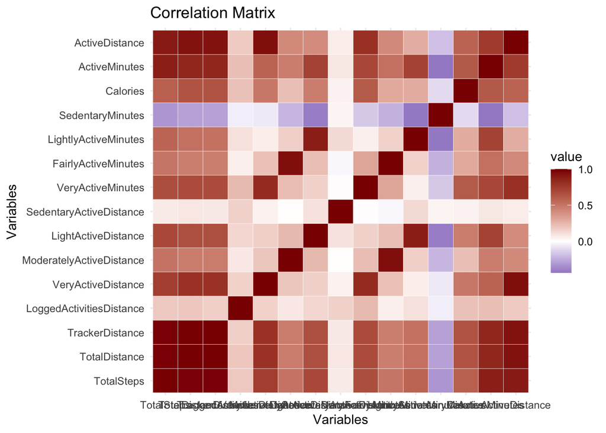

```r
# make correlation plot of df_dailyActivity
cor_matrix_dailyActivity <- cor(df_dailyActivity[, -c(1,2, 16)])

# Convert correlation matrix to long format
cor_data <- reshape2::melt(cor_matrix_dailyActivity)


# Plot correlation matrix
ggplot(cor_data, aes(x = Var1, y = Var2, fill = value)) +
  geom_tile(color = "white") +
  scale_fill_gradient2(low = "darkblue", mid = "white", high = "darkred", midpoint = 0) +
  labs(title = "Correlation Matrix",
       x = "Variables",
       y = "Variables") +
  theme_minimal()
```

This scatterplot below further explores the relationship between steps and active minutes. As depicted below, there is a strong positive relationship between the steps one takes and the total active minutes.

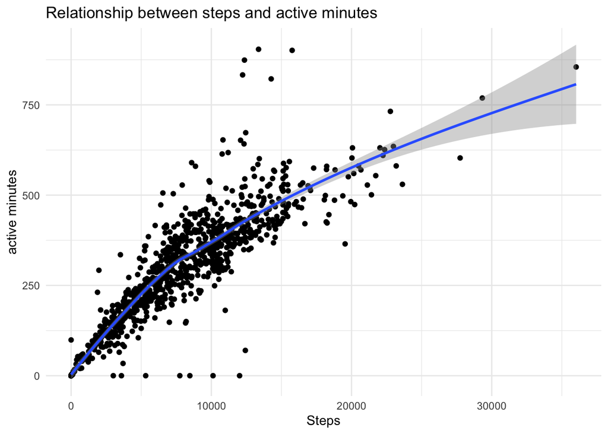

```r
ggplot(df_dailyActivity, aes(x = TotalSteps, y = ActiveMinutes)) +
  geom_point() +
  geom_smooth(method = "loess", se = TRUE, formula =  y ~ x) +
  labs(title = "Relationship between steps and active minutes",
       x = "Steps",
       y = "active minutes") +
  theme_minimal()
```

As shown in the correlation matrix sedentary minutes and active minutes have quite a negative correlation. When further exploring their relationship in a scatterplot, this shows a very interesting picture. There is not one general trend, but rather several trends. It seems as if there is no clear relationship between sedentary minutes and active minutes until around 1000 sedentary minutes a day. However, if sedentary minutes exceeds 1000, than there seems to be a clear, strong negative relationship.

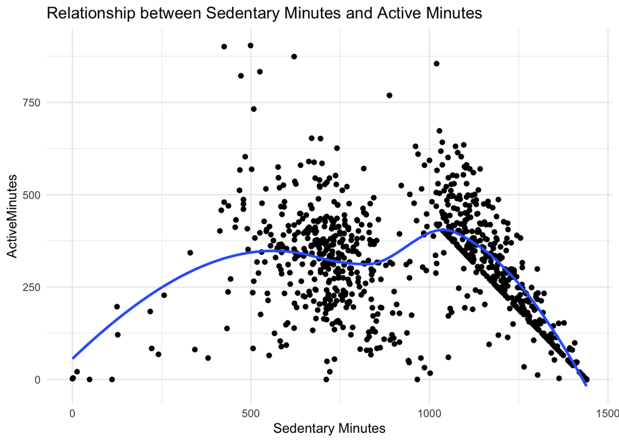

```r
ggplot(df_dailyActivity, aes(x = SedentaryMinutes, y = ActiveMinutes)) +
  geom_point() +
  geom_smooth(method = "loess", se = FALSE, formula =  y ~ x) +
  labs(title = "Relationship between Sedentary Minutes and Active Minutes",
       x = "Sedentary Minutes",
       y = "ActiveMinutes") +
  theme_minimal()
```

# 6. Further exploration of data

In the following the sleep data is merged with the daily activity data to see if there is some relationship.

```r
# Perform an inner join on "Id" and "ActivityDate" columns
merged_df_sleep_activity <- merge(df_sleepDay, df_dailyActivity, by = c("Id", "date"), all = FALSE)
```

Quite interestingly, sleep seems to not really have a relationship with daily activity. However, the negative relationship between sleep and sedentary minutes is outstanding and will be therefore further explored.

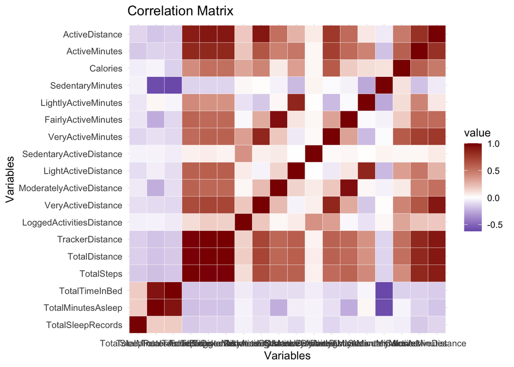

```r
# make correlation plot of df_dailyActivity
cor_matrix_dailyActivity <- cor(merged_df_sleep_activity[, -c(1,2,3,7)])

# Convert correlation matrix to long format
cor_data <- reshape2::melt(cor_matrix_dailyActivity)

# Plot correlation matrix
ggplot(cor_data, aes(x = Var1, y = Var2, fill = value)) +
  geom_tile(color = "white") +
  scale_fill_gradient2(low = "darkblue", mid = "white", high = "darkred", midpoint = 0) +
  labs(title = "Correlation Matrix",
       x = "Variables",
       y = "Variables") +
  theme_minimal()
```

As depicted below, there is a clear negative relationship between sleep and sedentary minutes. Meaning: The less one sleeps the liklier one is to spend a lot of time sitting.

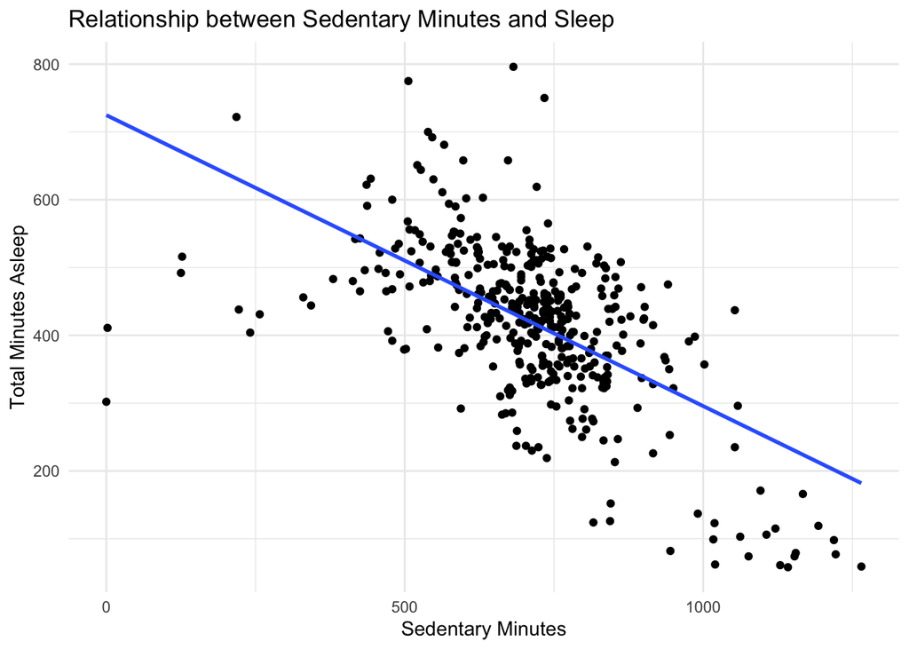

```r
# Example: Creating a scatter plot of "SedentaryMinutes" vs. "Sleep"
ggplot(merged_df_sleep_activity, aes(x = SedentaryMinutes, y = TotalMinutesAsleep)) +
  geom_point() +
  geom_smooth(method = "lm", se = FALSE, formula =  y ~ x) +
  labs(title = "Relationship between Sedentary Minutes and Sleep",
       x = "Sedentary Minutes",
       y = "Total Minutes Asleep") +
  theme_minimal()
```

Finally, when exploring the hour of the data when activity is the highest it can be seen, that especially from 17:00h-19:00h activity is the highest.

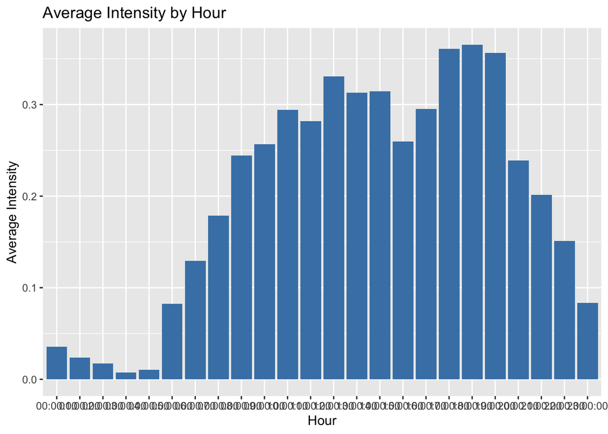

```r
average_intensity <- df_hourlyActivity_split %>%
  group_by(Hour) %>%
  summarize(AverageIntensity = mean(AverageIntensity))

ggplot(average_intensity, aes(x = Hour, y = AverageIntensity)) +
  geom_bar(stat = "identity", fill = "steelblue") +
  xlab("Hour") +
  ylab("Average Intensity") +
  ggtitle("Average Intensity by Hour")
```

# Conclusion

Based on the data analysis conducted for the BellaBeat company, several key findings have emerged:

1. Steps and active minutes: As illustrated, there seems to be a strong positive relationship between the number of steps taken and the total active minutes. This implies that individuals who take more steps are likely to have higher levels of physical activity.
2. Sedentary minutes: Sedentary minutes showed a negative correlation with almost all other variables. Further exploration through scatterplot analysis indicated that there is no clear relationship between sedentary minutes and active minutes until around 1000 sedentary minutes per day. However, if sedentary minutes exceed this threshold, a clear and strong negative relationship emerges.
3. Sleep and activity: Interestingly, sleep did not show a significant relationship with daily activity. However, there was a prominent negative relationship between sleep and sedentary minutes, suggesting that individuals who sleep less tend to spend more time sitting.
4. Peak activity hours: The analysis of activity levels throughout the day revealed that the highest levels of activity occur between 17:00h and 19:00h. This finding can help BellaBeat target specific time frames for promoting their products or engaging with their users.

# Recommendations:

Based on the findings, the following recommendations are proposed for BellaBeat:

1. Sedentary behavior awareness: BellaBeat should educate users about the negative impact of excessive sedentary behavior on health. By providing insights and reminders to break prolonged sitting periods, BellaBeat can help users reduce their sedentary minutes and improve overall well-being.
2. Sleep management: BellaBeat could develop features or programs to support better sleep habits among users. By providing personalized sleep recommendations, sleep tracking, and insights into the correlation between sleep and sedentary behavior, BellaBeat can help users establish healthier sleep routines.
3. Targeting peak activity hours: BellaBeat can leverage the information about peak activity hours (17:00h-19:00h) to promote their products or services during these periods. They could launch marketing campaigns, offer exclusive discounts, or organize events to engage users during these high-activity hours.
4. Further research: To gain a deeper understanding of the relationships identified in the analysis, BellaBeat could consider conducting additional research, such as surveys or user studies. This can provide valuable insights into user preferences, motivations, and barriers related to physical activity, sedentary behavior, and sleep patterns.

By implementing these recommendations, BellaBeat can enhance user engagement, promote healthier behaviors, and strengthen their position as a leading provider of wellness products and services.